[← Volver a Día 1](https://valentinzarate.github.io/taller_mov/tema_1/tema1.html)

# Rasters

```r
library(terra)
```

# Rasters

## Rasters: el espacio como una grilla regular

En ecología de movimientos, los objetos raster permiten representar variables ambientales continuas o categóricas sobre el espacio. A diferencia de un `data.frame`, donde cada fila suele representar una observación, un raster divide el espacio en celdas regulares. Cada celda contiene un valor: cobertura del suelo, distancia al agua, distancia a urbanización, pendiente, temperatura, productividad, riesgo, o cualquier otra variable ambiental relevante.

En este taller vamos a usar objetos `SpatRaster` del paquete `terra`. Aunque muchas veces se habla de *raster stack*, en `terra` varias capas apiladas se almacenan en un único objeto `SpatRaster` multicapa.

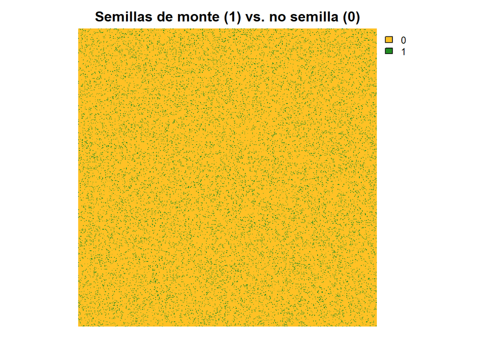

```r
r <- rast(nrows = 500, ncols = 500, xmin = 0, xmax = 500, ymin = 0, ymax = 500)

# semillas de monte (7 %)
seeds <- r
values(seeds) <- rbinom(ncell(seeds), 1, 0.07)


plot(seeds, main = "Semillas de monte (1) vs. no semilla (0)",
     col = c("goldenrod1", "forestgreen"), axes = FALSE)
```

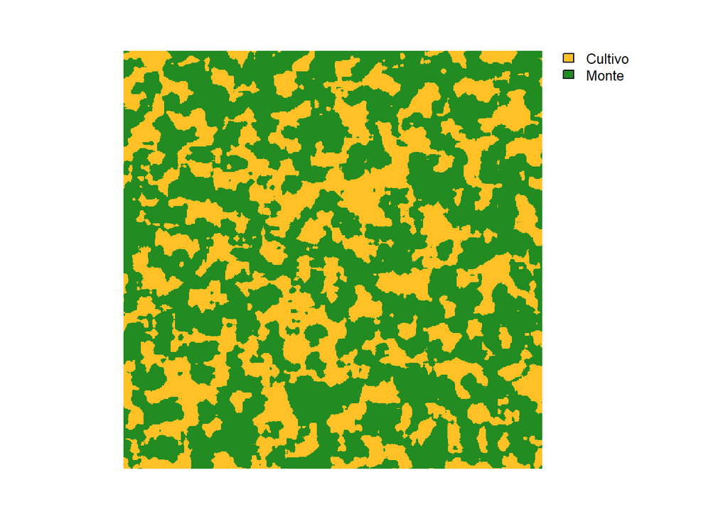

```r
# suavizado doble
kern_big  <- matrix(1, 17,17)
kern_fine <- matrix(1, 5, 5)
smooth1 <- focal(seeds, w = kern_big,  fun = mean, na.policy = "omit")
smooth2 <- focal(smooth1, w = kern_fine, fun = mean, na.policy = "omit")

# umbral dinámico: cuantil 0.6 ≈ 40% monte
thr <- quantile(values(smooth2), 0.4, na.rm = TRUE)
cover <- classify(smooth2, rcl = matrix(c(-Inf, thr, 0,
                                          thr, Inf, 1), ncol = 3, byrow = TRUE))
names(cover) <- "cover"

# si todo quedó en 0, fuerza 15% a 1 (igual que antes)
if (all(values(cover) == 0)) {
  ids <- sample(ncell(cover), size = ceiling(0.15 * ncell(cover)))
  v <- values(cover); v[ids] <- 1; values(cover) <- v
}

# declarar como factor y nombrar categorías
cover <- as.factor(cover)
levels(cover) <- data.frame(ID = c(0, 1),
                            cover = c("Cultivo", "Monte"))  # nombre de la columna de niveles = nombre de la capa


plot(cover,
     col = c("goldenrod1", "forestgreen"), axes = FALSE)
```

```r
# (opcional) definir CRS si lo necesitas para RSF/SSF espaciales
crs(cover) <- "EPSG:4326"  # o el que corresponda; si solo es didáctico puedes omitirlo


# (opcional) guardar a archivo para reutilizar
writeRaster(cover, "cover_cat.tif", overwrite = TRUE)
```

Inspeccionmamos un poco el objeto para entender con que estamos trabajando

```r
dim(cover)
```

```
## [1] 500 500   1
```

```r
nlyr(cover)
```

```
## [1] 1
```

```r
res(cover)
```

```
## [1] 1 1
```

```r
crs(cover)
```

```
## [1] "GEOGCRS[\"WGS 84\",\n    ENSEMBLE[\"World Geodetic System 1984 ensemble\",\n        MEMBER[\"World Geodetic System 1984 (Transit)\"],\n        MEMBER[\"World Geodetic System 1984 (G730)\"],\n        MEMBER[\"World Geodetic System 1984 (G873)\"],\n        MEMBER[\"World Geodetic System 1984 (…
```

Podemos desarmarlo en una Df, aunque muchas veces no es conveniente porque suelen ser gigantes… pero a los fines de entender qué tiene adentro si tiene sentido

```r
df <- as.data.frame(cover, xy = TRUE, cells = TRUE)
ncell(cover)
```

```
## [1] 250000
```

```r
head(df)
```

|  | cell | x | y | cover |
| --- | --- | --- | --- | --- |
| 5011 | 5011 | 10.5 | 489.5 | Monte |
| 5012 | 5012 | 11.5 | 489.5 | Monte |
| 5013 | 5013 | 12.5 | 489.5 | Monte |
| 5014 | 5014 | 13.5 | 489.5 | Monte |
| 5015 | 5015 | 14.5 | 489.5 | Monte |
| 5016 | 5016 | 15.5 | 489.5 | Monte |

**Estrucutra del Raster**

En este caso nos está mostrando que una columna representa el ID de la celda, empezando de la esquina izquierda superior

$x$, $y$ son las coordenadas del centro de la celda para ubicar cada pixel en el espaco “real”.

en Este caso, aunque esto variará mucho en cada Raster, **cover** es un atributo asociado a cada pixel (podría ser otra cateogría o algo númerico como el NDVI)

Otra alternativa

```r
df_long <- df |>
  tidyr::pivot_longer(
    cols = -c(cell, x, y),
    names_to = "variable",
    values_to = "value"
  )

df_long
```

| cell | x | y | variable | value |
| --- | --- | --- | --- | --- |
| 5011 | 10.5 | 489.5 | cover | Monte |
| 5012 | 11.5 | 489.5 | cover | Monte |
| 5013 | 12.5 | 489.5 | cover | Monte |
| 5014 | 13.5 | 489.5 | cover | Monte |
| 5015 | 14.5 | 489.5 | cover | Monte |
| 5016 | 15.5 | 489.5 | cover | Monte |
| 5017 | 16.5 | 489.5 | cover | Cultivo |
| 5018 | 17.5 | 489.5 | cover | Cultivo |
| 5019 | 18.5 | 489.5 | cover | Cultivo |
| 5020 | 19.5 | 489.5 | cover | Cultivo |

[output cut: 9990 more lines]

### Urbanizaciones como polígonos

Podemos representar urbanizaciones como polígonos vectoriales. Luego, esos polígonos se pueden rasterizar para construir una capa ambiental con presencia o ausencia de urbanización. Esta operación es frecuente cuando queremos combinar información vectorial, como caminos, ríos o ciudades, con capas raster ambientales.

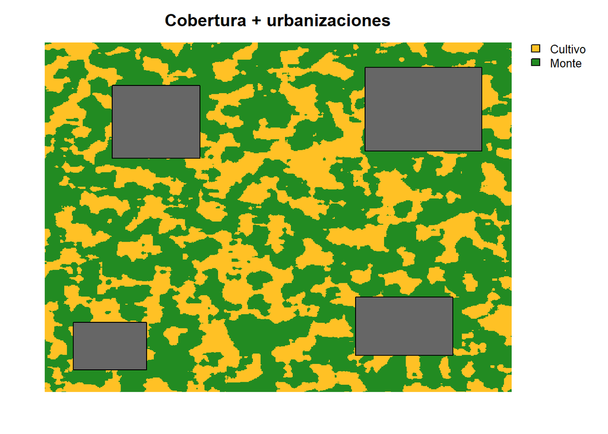

```r
# Crear cuatro polígonos de urbanización dentro del mismo sistema de coordenadas
require(sf)
urban_sf <- st_sf(
  id = 1:4,
  geometry = st_sfc(
    st_polygon(list(matrix(c(
       40,  40,
      115,  40,
      115, 105,
       40, 105,
       40,  40
    ), ncol = 2, byrow = TRUE))),

    st_polygon(list(matrix(c(
      330,  60,
      430,  60,
      430, 140,
      330, 140,
      330,  60
    ), ncol = 2, byrow = TRUE))),

    st_polygon(list(matrix(c(
       80, 330,
      170, 330,
      170, 430,
       80, 430,
       80, 330
    ), ncol = 2, byrow = TRUE))),

    st_polygon(list(matrix(c(
      340, 340,
      460, 340,
      460, 455,
      340, 455,
      340, 340
    ), ncol = 2, byrow = TRUE)))
  )
)

# Convertir sf a vect para usar con terra
urban_v <- vect(urban_sf)

plot(cover,
     col = c("goldenrod1", "forestgreen"),
     axes = FALSE,
     main = "Cobertura + urbanizaciones")
plot(urban_v, add = TRUE, col = "grey40", border = "black")
```

Acá creamos dos objetos equivalentes: un `SpatVector` y un `SF`. Ambos representan una forma geometrica en el espacio (un Shapefile), pero con distinos formatos asociados a distintos paquentes de R. Aunque en el script se puede ver que son muy intercambiables. Ahí vimos cómo llevarlo desde el mundito de *sf* al de *terra*. Si quisiesemos hacer lo inverso (muchas veces más conveniente en movimientos), podemos hace esto

`urban_sf2 <- st_as_sf(urban_v)`

Más aun, podemos rasterizar los vectores de una manera bastante simple.. en este caso le asignamos a los pixeles 1 y 0, pero podríamos complejizarlo más si quisiesemos.

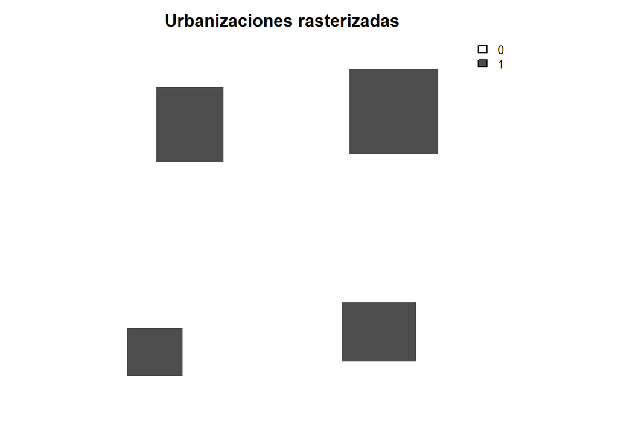

```r
# Rasterizar urbanizaciones: 1 = urbano, 0 = no urbano
urban <- rasterize(urban_v, r, field = 1, background = 0)
names(urban) <- "urban"

plot(urban,
     col = c("white", "grey30"),
     axes = FALSE,
     main = "Urbanizaciones rasterizadas")
```

Básicamente lo mismo pero con otra estructura interna. Estos intercambios son muy convenientes en análisis, sea en la dirección que sea.

### Agregando ríos como líneas sinuosas

Los ríos pueden representarse inicialmente como líneas. Para transformarlos en una capa raster podemos rasterizar la línea directamente, o bien crear primero un buffer y luego rasterizar ese buffer. La segunda opción suele ser más útil didácticamente, porque permite representar una franja ribereña o zona de influencia del río.

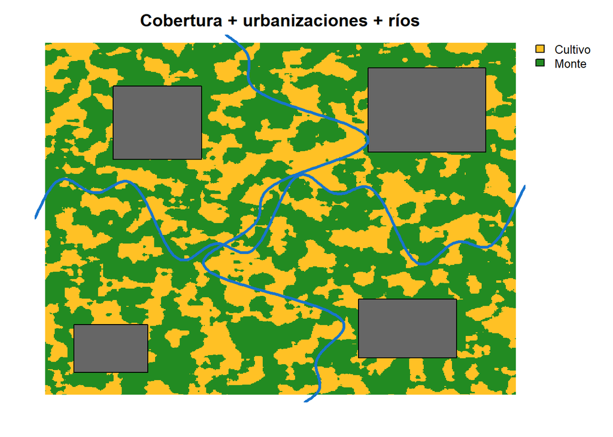

```r
x1 <- seq(0, 500, length.out = 300)
y1 <- 250 + 55 * sin(x1 / 38) + 20 * sin(x1 / 13)

river1 <- st_linestring(cbind(x1, y1))

y2 <- seq(0, 500, length.out = 300)
x2 <- 250 + 65 * sin(y2 / 45) + 25 * cos(y2 / 19)

river2 <- st_linestring(cbind(x2, y2))

rivers_sf <- st_sf(
  id = 1:2,
  geometry = st_sfc(river1, river2)
)

rivers_v <- vect(rivers_sf)

plot(cover,
     col = c("goldenrod1", "forestgreen"),
     axes = FALSE,
     main = "Cobertura + urbanizaciones + ríos")
plot(urban_v, add = TRUE, col = "grey40", border = "black")
plot(rivers_v, add = TRUE, col = "dodgerblue3", lwd = 3)
```

Los vectores pueden ser lineas también, o puntos, o multipoligonos como antes. Acá agrando las lineas con una función que es muy muy usada en ecología: `buffer`. Sirve por ejemplo para “agrandar” puntos y calcular % de elementos del pasiaje dentro de dicho buffer.

```r
# Crear buffer alrededor de los ríos
rivers_buffer <- buffer(rivers_v, width = 8)

# Rasterizar el buffer ribereño
river <- rasterize(rivers_buffer, r, field = 1, background = 0)
names(river) <- "river"

class(river)
```

```
## [1] "SpatRaster"
## attr(,"package")
## [1] "terra"
```

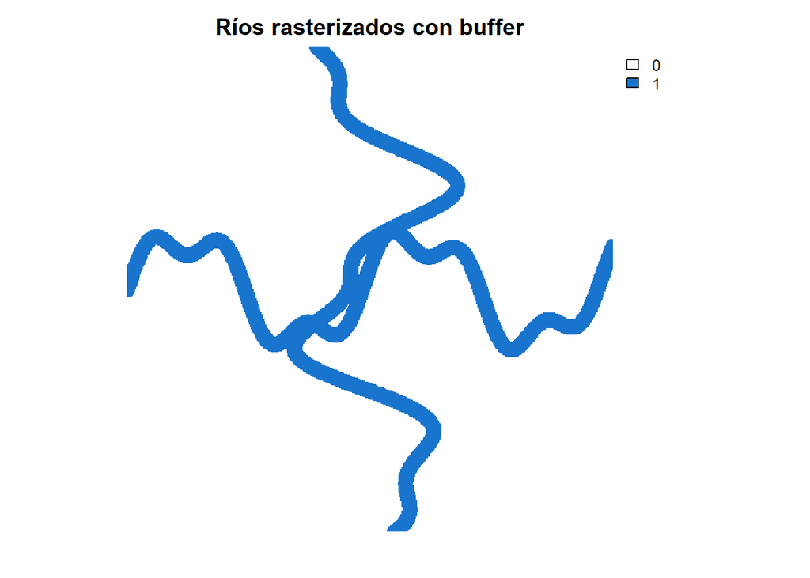

```r
plot(river,
     col = c("white", "dodgerblue3"),
     axes = FALSE,
     main = "Ríos rasterizados con buffer")
```

### Construcción de un raster multicapa

Finalmente podemos apilar las capas en un único objeto raster multicapa. Este objeto reúne variables categóricas, binarias y continuas en una misma estructura espacial. En análisis de selección de hábitat, RSF o SSF, este tipo de objeto permite extraer covariables ambientales para puntos usados y disponibles. Es muy útil actualmente, es muy común trabajar con más de una capa raster y tenerlos en un “Stack” automatiza varias cosas, como extraer todos los datos de un solo paso.

**Nota**: Es importante compatilizar los rasters antes, misma resolución, mismo cRS y misma extensión (este ultimo es más negociable).

```r
# Para apilar, conviene usar la versión numérica de cover
cover_num <- cover
cover_num <- as.numeric(cover_num)
names(cover_num) <- "cover_num"

env_stack <- c(
  cover_num,
  urban,
  river)

env_stack
```

```
## class       : SpatRaster
## size        : 500, 500, 3  (nrow, ncol, nlyr)
## resolution  : 1, 1  (x, y)
## extent      : 0, 500, 0, 500  (xmin, xmax, ymin, ymax)
## coord. ref. : lon/lat WGS 84 (EPSG:4326)
## source(s)   : memory
## names       : cover_num, urban, river
## min values  :         0,     0,     0
## max values  :         1,     1,     1
```

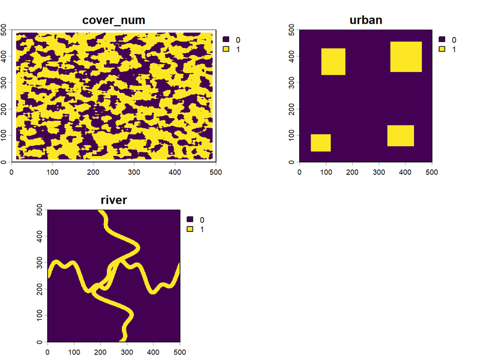

```r
plot(env_stack)
```

```r
readr::write_rds(env_stack, "env_stack.rds")
```

## SpatRasters

Un `SpatRaster` es un objeto del paquete `terra` que representa el espacio como una grilla regular de celdas. Cada celda tiene una ubicación en el plano y puede contener uno o más valores.

A diferencia de un `data.frame`, donde las filas representan observaciones, en un raster las **observaciones son celdas espaciales**.

Esto significa que el raster define una estructura espacial explícita: cada valor está asociado a una posición $(x, y)$ dentro de una grilla.

$$\text{Espacio} \rightarrow \text{grilla regular de celdas}$$

### Componentes de un SpatRaster

Todo `SpatRaster` tiene tres componentes fundamentales:

- **Extensión espacial**: define los límites del área de estudio
- **Resolución**: tamaño de cada celda
- **Valores**: el contenido de cada celda

Estos elementos definen completamente cómo se representa el espacio.

## Capas (layers): variables en el espacio

Un `SpatRaster` puede contener una o varias capas. Cada capa representa una variable ambiental distinta, pero todas comparten exactamente la misma geometría.

En nuestro caso, el objeto `env_stack` contiene varias capas:

```r
names(env_stack)
```

```
## [1] "cover_num" "urban"     "river"
```

- `cover_num`: tipo de cobertura
- `urban`: presencia de urbanización
- `river`: presencia de ríos

Podemos pensar cada capa como una “columna espacial”.

$$(x, y) \rightarrow (z_1, z_2, z_3)$$

donde cada $z_k$ es una variable distinta definida en la misma celda.

### Accediendo a capas individuales

```r
# Acceder por nombre
env_stack$cover_num
```

```
## class       : SpatRaster
## size        : 500, 500, 1  (nrow, ncol, nlyr)
## resolution  : 1, 1  (x, y)
## extent      : 0, 500, 0, 500  (xmin, xmax, ymin, ymax)
## coord. ref. : lon/lat WGS 84 (EPSG:4326)
## source(s)   : memory
## name        : cover_num
## min value   :         0
## max value   :         1
```

```r
# Acceder por índice
env_stack[[1]]
```

```
## class       : SpatRaster
## size        : 500, 500, 1  (nrow, ncol, nlyr)
## resolution  : 1, 1  (x, y)
## extent      : 0, 500, 0, 500  (xmin, xmax, ymin, ymax)
## coord. ref. : lon/lat WGS 84 (EPSG:4326)
## source(s)   : memory
## name        : cover_num
## min value   :         0
## max value   :         1
```

Cada una de estas operaciones devuelve un **SpatRaster de una sola capa**. Es decir, seguimos trabajando con objetos espaciales, no con vectores simples.

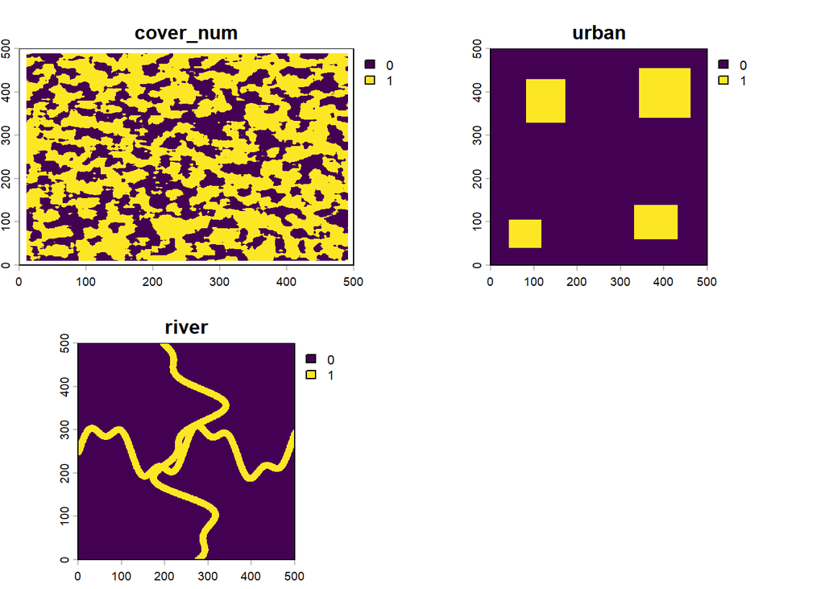

```r
plot(env_stack)
```

## De raster a datos: extracción de información

El uso más importante de un `SpatRaster` en ecología de movimientos es extraer información ambiental en ubicaciones específicas.

Por ejemplo, podemos tener puntos de GPS de un animal y querer saber:

- ¿Está en monte o cultivo?
- ¿Está cerca de un río?
- ¿Está en zona urbanizada?

Esto se hace mediante la función `extract()`.

```r
# Crear puntos de ejemplo
pts <- data.frame(
  id = 1:5,
  x = runif(5, 0, 500),
  y = runif(5, 0, 500)
)

library(sf)
pts_sf <- st_as_sf(pts, coords = c("x", "y"))

library(terra)
pts_v <- vect(pts_sf)

# Extraer valores
vals <- extract(env_stack, pts_v)

vals
```

| ID | cover_num | urban | river |
| --- | --- | --- | --- |
| 1 | 1 | 0 | 0 |
| 2 | 0 | 0 | 0 |
| 3 | 1 | 0 | 0 |
| 4 | 0 | 1 | 0 |
| 5 | 0 | 0 | 0 |

### Interpretación

El resultado de `extract()` es un `data.frame` donde:

- Cada fila es un punto
- Cada columna es una capa del raster

Es decir, estamos transformando información espacial en un formato tabular.

$$(x, y) \rightarrow \text{fila en un data.frame}$$

Este paso es clave porque conecta dos mundos:

- El mundo espacial (rasters)
- El mundo estadístico (data.frames)

A partir de aquí, estas variables pueden utilizarse en modelos como RSF o SSF.

## ¿Se puede usar `extract()` con líneas?

Sí, la función `extract()` también puede utilizarse con líneas. Esto permite analizar qué ambientes atraviesa una trayectoria.

Sin embargo, a diferencia de los puntos, aquí aparece una decisión importante: **¿qué significa “extraer” valores a lo largo de una línea?**

### Dos formas principales de trabajar con líneas

Cuando usamos líneas, existen dos enfoques conceptuales distintos:

- **Muestreo a lo largo de la línea** (qué valores se encuentran en el recorrido)
- **Resumen sobre la línea** (promedio, suma, proporción, etc.)

### Muestrear qué ambientes atraviesa

Si queremos saber *qué ambientes atraviesa una trayectoria*, una estrategia común es convertir la línea en muchos puntos (muestreo) y luego usar `extract()`.

Esto transforma la línea en una secuencia de observaciones espaciales.

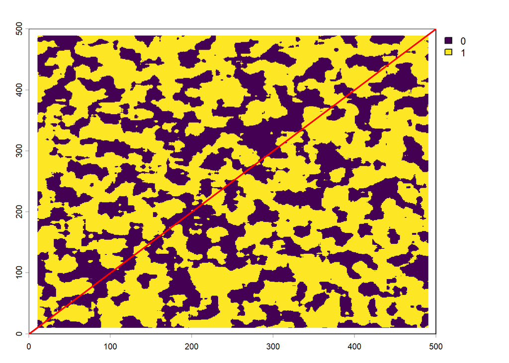

```r
# Crear una línea de ejemplo (puede ser un track simplificado)
line_sf <- st_sf(
  id = 1,
  geometry = st_sfc(
    st_linestring(matrix(c(
      0, 0,
      500, 500
    ), ncol = 2, byrow = TRUE))
  )
)

line_v <- vect(line_sf)

plot(env_stack$cover_num)
plot(line_v, add = TRUE, col = "red", lwd = 2)
```

```r
# Muestrear puntos a lo largo de la línea
pts_line <- spatSample(line_v, size = 100, method = "regular")

# Extraer valores
vals_line <- extract(env_stack, pts_line)

head(vals_line)
```

|  | ID | cover_num | urban | river |
| --- | --- | --- | --- | --- |
| 1 | 1 | NA | 0 | 0 |
| 2 | 2 | NA | 0 | 0 |
| 3 | 3 | 0 | 0 | 0 |
| 4 | 4 | 1 | 0 | 0 |
| 5 | 5 | 0 | 0 | 0 |
| 6 | 6 | 1 | 0 | 0 |

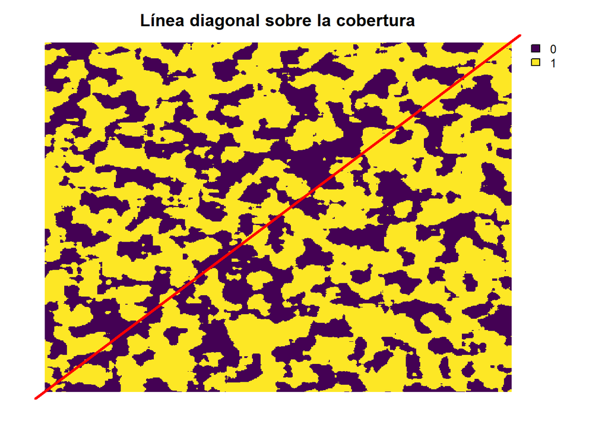

```r
# Línea diagonal desde la esquina inferior izquierda a la superior derecha
line_sf <- st_sf(
  id = 1,
  geometry = st_sfc(
    st_linestring(matrix(c(
      0,   0,
      500, 500
    ), ncol = 2, byrow = TRUE))
  )
)

line_v <- vect(line_sf)

plot(env_stack$cover_num,
     axes = FALSE,
     main = "Línea diagonal sobre la cobertura")
plot(line_v, add = TRUE, col = "red", lwd = 3)
```

Para saber qué ambientes atraviesa, primero convertimos la línea en muchos puntos ordenados a lo largo del recorrido. Luego usamos `extract()` para obtener los valores ambientales en cada punto.

```r
# Crear puntos regularmente espaciados sobre la línea
pts_line_geom <- st_line_sample(line_sf, n = 200)

# Extraer la colección de puntos y convertirla a sfc_POINT
pts_line_geom <- st_cast(pts_line_geom, "POINT")

# Crear sf con un ID ordenado
pts_line_sf <- st_sf(
  punto = seq_along(pts_line_geom),
  geometry = pts_line_geom
)

pts_line_v <- vect(pts_line_sf)

# Extraer valores del raster multicapa
vals_line <- extract(env_stack, pts_line_v)

# Unir con el orden de los puntos
vals_line$punto <- pts_line_sf$punto

head(vals_line)
```

|  | ID | cover_num | urban | river | punto |
| --- | --- | --- | --- | --- | --- |
| 1 | 1 | NA | 0 | 0 | 1 |
| 2 | 2 | NA | 0 | 0 | 2 |
| 3 | 3 | NA | 0 | 0 | 3 |
| 4 | 4 | NA | 0 | 0 | 4 |
| 5 | 5 | 0 | 0 | 0 | 5 |
| 6 | 6 | 0 | 0 | 0 | 6 |

```r
pts_line_geom <- st_cast(pts_line_geom, "POINT")
```

### Secuencia de ambientes a lo largo del recorrido

Este gráfico muestra cómo cambia el ambiente a medida que avanzamos a lo largo de la línea.

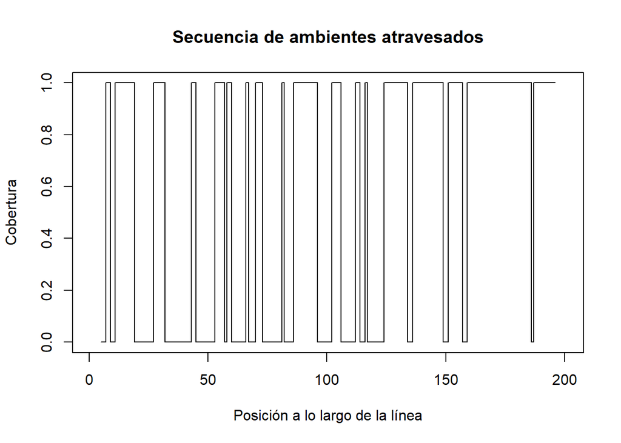

```r
plot(
  vals_line$punto,
  vals_line$cover_num,
  type = "s",
  xlab = "Posición a lo largo de la línea",
  ylab = "Cobertura",
  main = "Secuencia de ambientes atravesados"
)
```

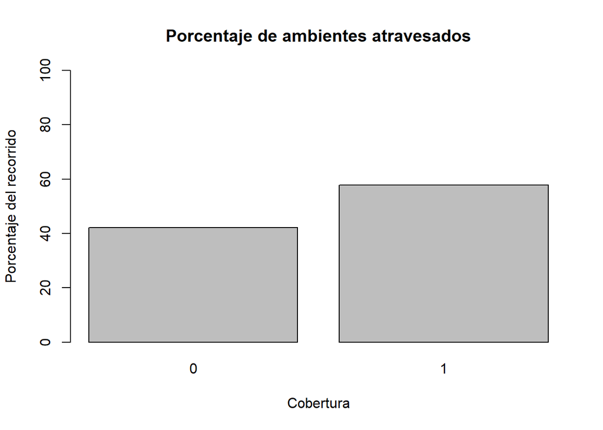

```r
porc_cover <- prop.table(table(vals_line$cover_num)) * 100

barplot(
  porc_cover,
  ylab = "Porcentaje del recorrido",
  xlab = "Cobertura",
  main = "Porcentaje de ambientes atravesados",
  ylim = c(0, 100)
)
```

## MapBiomas

```r
cols5 <- c(
  "#518746",  # Bosques cerrados (bosque nativo)
  "#7a5900",  # Silvicultura
  "#ffefc3",  # Agropecuario (pasturas+cultivos+mosaico)
  "grey32",  # Urbano/no veg (urbano)
  "#6CE4E6"   # Agua
)

map <- rast("data/spatial/mapbiomas2024_misiones_5clases.tif")


class(map)
```

```
## [1] "SpatRaster"
## attr(,"package")
## [1] "terra"
```

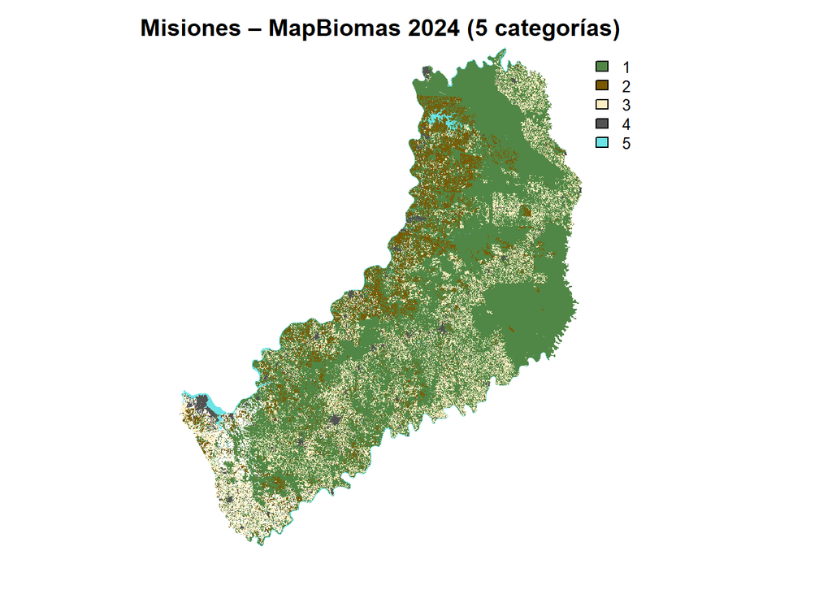

```r
plot(map, col = cols5, axes = FALSE, main = "Misiones – MapBiomas 2024 (5 categorías)")
```

Agregamos un shapefile de la provincia

```r
prov <- vect("data/spatial/provincia.shp")
```

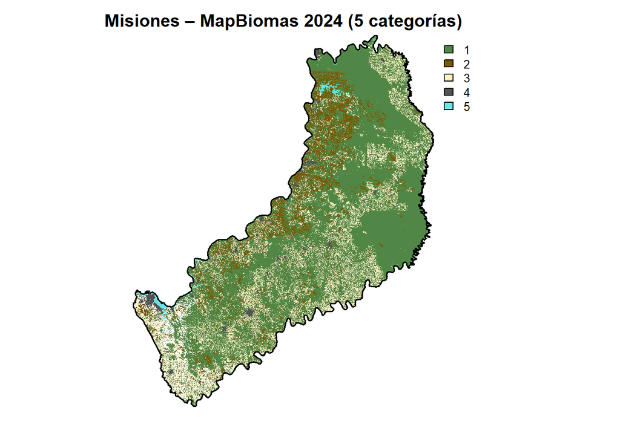

```r
plot(map,
     col = cols5,
     axes = FALSE,
     main = "Misiones – MapBiomas 2024 (5 categorías)")

plot(
  prov,
  add = TRUE,
  border = "black",
  lwd = 1.8
)
```

Bien, de pedo dió bien… pero deberíaoms haber chequeado el CRS antes

```r
crs(prov)
```

```
## [1] "GEOGCRS[\"WGS 84\",\n    DATUM[\"World Geodetic System 1984\",\n        ELLIPSOID[\"WGS 84\",6378137,298.257223563,\n            LENGTHUNIT[\"metre\",1]]],\n    PRIMEM[\"Greenwich\",0,\n        ANGLEUNIT[\"degree\",0.0174532925199433]],\n    CS[ellipsoidal,2],\n        AXIS[\"geodetic latitu…
```

```r
crs(map)
```

```
## [1] "GEOGCRS[\"WGS 84\",\n    ENSEMBLE[\"World Geodetic System 1984 ensemble\",\n        MEMBER[\"World Geodetic System 1984 (Transit)\"],\n        MEMBER[\"World Geodetic System 1984 (G730)\"],\n        MEMBER[\"World Geodetic System 1984 (G873)\"],\n        MEMBER[\"World Geodetic System 1984 (…
```

```r
prov <- project(prov, crs(map))
```

```r
names(levels(map)[[1]])
```

```r
levels(map) <- data.frame(
  value = 1:5,
  category = c("Bosque_nativo",
               "Silvicultura",
               "Agro_rural",
               "Urbano_no_veg",
               "Agua")
)
```

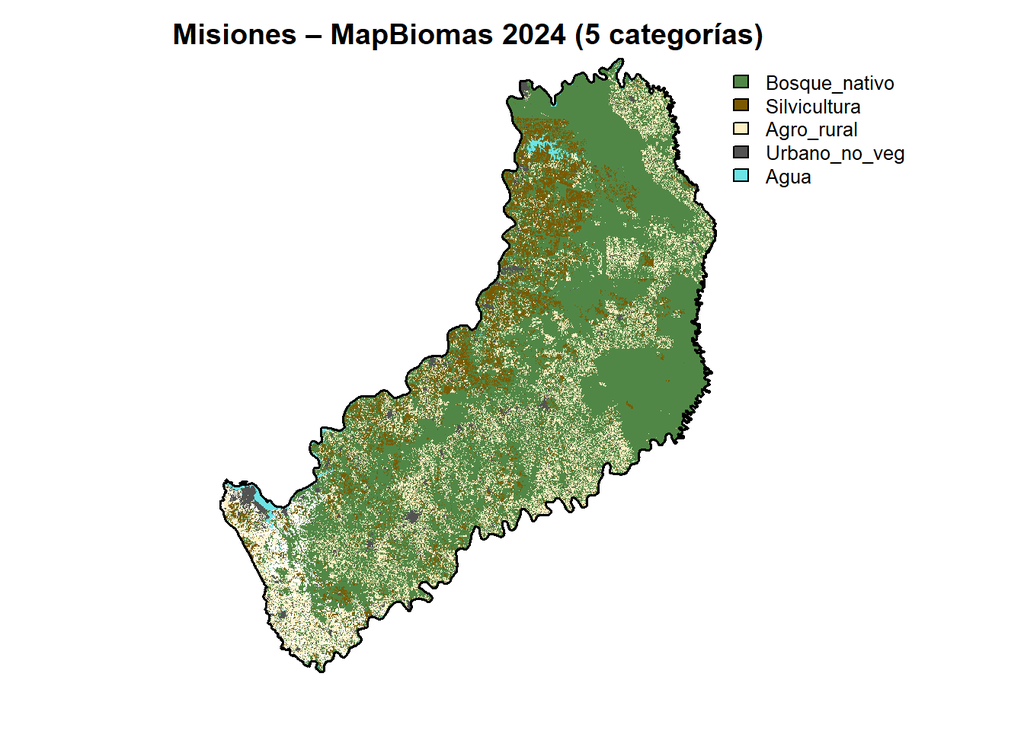

```r
plot(map,
     col = cols5,
     axes = FALSE,
     main = "Misiones – MapBiomas 2024 (5 categorías)")

plot(
  prov,
  add = TRUE,
  border = "black",
  lwd = 1.8
)
```

## ¿Qué tipo de objeto es un raster en R?

Un raster de `terra`, como un `SpatRaster`, no es un `data.frame`, ni una matriz simple, ni una lista común. Es un **objeto espacial especializado**.

Sin embargo, internamente combina ideas que ya conocemos de otros objetos de R:

- **Matriz**: porque organiza valores en filas y columnas espaciales.
- **Lista**: porque puede contener varias capas y metadatos asociados.
- **Factor**: cuando representa categorías, como tipos de cobertura.
- **Objeto espacial**: porque además guarda extensión, resolución y sistema de coordenadas.

### Comparación con `sf`

Un objeto `sf` se parece mucho a un `data.frame`. De hecho, podemos pensarlo como una tabla con una columna especial de geometría.

En cambio, un `SpatRaster` no organiza la información en filas explícitas, sino en una grilla regular.

- **`sf`**: cada fila es una entidad espacial, como un punto, una línea o un polígono.
- **`SpatRaster`**: cada celda es una unidad espacial, aunque no aparezca como una fila visible.

### La diferencia central

En un `sf`, la geometría está guardada explícitamente en una columna:

$$\text{fila}_i = (\text{atributos}_i, \text{geometría}_i)$$

En un raster, la geometría está implícita en la grilla:

$$\text{celda}_i = (x_i, y_i, z_i)$$

Pero normalmente no vemos una fila por celda. El objeto guarda la regla espacial: extensión, resolución, número de filas y columnas. Con esa información, R sabe dónde está cada celda.

### Raster como una tabla espacial implícita

Aunque no sea un `data.frame`, podemos imaginar un raster multicapa como una tabla espacial implícita:

$$(x, y) \rightarrow (z_1, z_2, z_3, \dots, z_k)$$

donde cada `z` es una capa: cobertura, urbanización, río, elevación, distancia al agua, etc.

La diferencia es que esa tabla no está desplegada en memoria como filas y columnas. Está representada de forma compacta como una grilla.

En un `data.frame`, usaríamos `names()` para ver nombres de columnas. En un `SpatRaster`, `names()` muestra los nombres de las capas.

### Pero no son data.frames

La diferencia importante es que en un `data.frame` las filas están explícitas. En un raster, las celdas existen espacialmente, pero no aparecen como filas hasta que las convertimos.

```r
map_df <- as.data.frame(map, xy = TRUE)
head(map_df)
```

|  | x | y | category |
| --- | --- | --- | --- |
| 16235 | -54.10468 | -25.49459 | Agua |
| 16236 | -54.10441 | -25.49459 | Agua |
| 16237 | -54.10414 | -25.49459 | Agua |
| 16238 | -54.10387 | -25.49459 | Agua |
| 16239 | -54.10360 | -25.49459 | Agua |
| 16240 | -54.10333 | -25.49459 | Agua |

```r
str(map_df)
```

```
## 'data.frame':    36388906 obs. of  3 variables:
##  $ x       : num  -54.1 -54.1 -54.1 -54.1 -54.1 ...
##  $ y       : num  -25.5 -25.5 -25.5 -25.5 -25.5 ...
##  $ category: Factor w/ 5 levels "Bosque_nativo",..: 5 5 5 5 5 5 5 5 5 5 ...
```

Al usar `as.data.frame(map, xy = TRUE)`, el raster se despliega como una tabla: una fila por celda, columnas `x` e `y`, y una columna con el valor del raster.

Esto es útil para entender la estructura, pero puede ser muy costoso en memoria si el raster tiene millones de celdas.

### Usos de suelo + Traycetoria

Vamos a hacer una simulación super simple de una trayectoria para ver algo útil en casi todos los análisis de ecología de movimientos

```r
e <- ext(map)

# dos puntos (inicio y fin)
line_coords <- rbind(
  c(e$xmin, (e$ymin + e$ymax)/2),  # izquierda centro
  c(e$xmax, (e$ymin + e$ymax)/2)   # derecha centro
)
```

```r
line <- vect(
  line_coords,
  type = "lines",
  crs = crs(map)
)

line_coords <- rbind(
  c(e$xmin, e$ymin),
  c(e$xmax, e$ymax)
)

x_seq <- seq(e$xmin, e$xmax, length.out = 100)
y_seq <- seq(e$ymin, e$ymax, length.out = 100)

line_coords <- cbind(x_seq, y_seq)

line <- vect(line_coords, type = "lines", crs = crs(map))
```

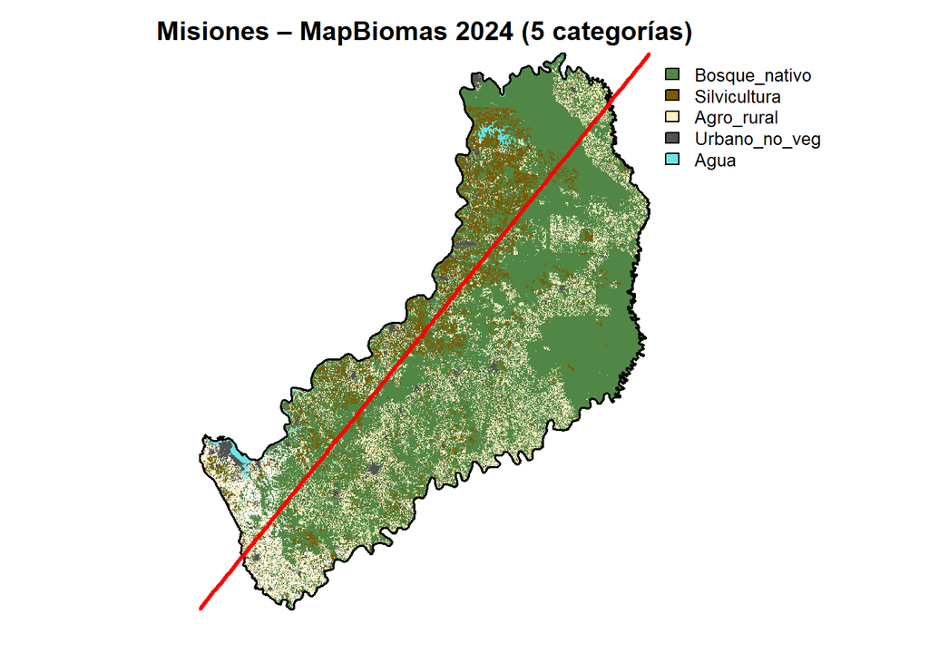

```r
plot(map,
     col = cols5,
     axes = FALSE,
     main = "Misiones – MapBiomas 2024 (5 categorías)")

plot(
  prov,
  add = TRUE,
  border = "black",
  lwd = 1.8
)

# agregar la línea
plot(line, add = TRUE, col = "red", lwd = 3)
```

Fácilmente podemos ver por dónde pasó esa linea

```r
vals_line <- terra::extract(map, line)
```

```r
table(vals_line$category)
```

```
##
## Bosque_nativo  Silvicultura    Agro_rural Urbano_no_veg          Agua
##          9723          2567          2210           300             9
```

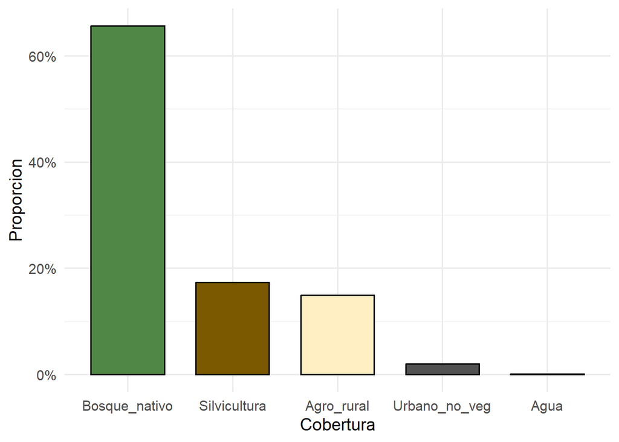

```r
tab <- table(vals_line$category)
prop <- prop.table(tab)

df_prop <- as.data.frame(prop)
names(df_prop) <- c("category", "prop")

require(ggplot2)

ggplot(df_prop, aes(x = category, y = prop, fill = category)) +
  geom_col(width = 0.7, color = "black", linewidth = 0.6) +
  scale_fill_manual(values = cols5, guide = "none") +
  scale_y_continuous(labels = scales::percent) +
  labs(
    x = "Cobertura",
    y = "Proporcion"
  ) +
  theme_minimal(base_size = 14)
```

```r
seq_cover <- vals_line |>
  dplyr::mutate(
    paso = dplyr::row_number(),
    category = factor(category)
  ) |> na.omit()
```

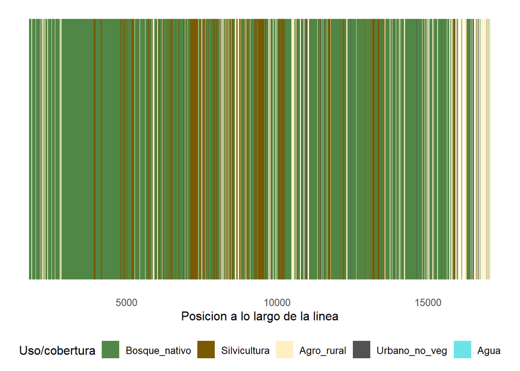

```r
ggplot(seq_cover, aes(x = paso, y = 1, fill = category)) +
  geom_tile(height = 0.15) +
  scale_fill_manual(
    values = cols5,
    name = "Uso/cobertura"
  ) +
  labs(
    x = "Posicion a lo largo de la linea",
    y = NULL) +
  theme_minimal(base_size = 12) +
  theme(
    axis.text.y = element_blank(),
    axis.ticks.y = element_blank(),
    panel.grid = element_blank(),
    legend.position = "bottom",
    plot.title = element_text(face = "bold"))
```